# Notes

```python
import matplotlib.pyplot as plt
import numpy as np
```

```python
def plot_cobweb( ax, f, x0, iters = 5 ):
    """Adds a cobweb plot line to the desired axis"""
    ys = [0]
    xs = [x0]

    for i in range( iters ):
        ys.append( f( xs[-1] ) )
        xs.append( xs[-1] )

        if i < iters - 1:
            ys.append( ys[-1] )
            xs.append( ys[-1] )

    ax.plot( xs, ys, '--', label = str(x0) )
    return xs[::2]
```

## 2019 - 01 - 15

Two classes of dynamical systems:

- discrete-time: take current state as input, produce new state as output
- continuous-time: limit as discrete system update time goes to zero

Define $f^k(x)$ as applying the function $f$ $k$ times

\begin{array} f(x) &= 3x\\ x_0 &= \frac{1}{6}, \quad f(x_0) &= 3 * \frac{1}{6} = \frac{1}{2} \\ x_1 &= \frac{1}{2}, \quad f(x_1) &= 3 * \frac{1}{2} = \frac{3}{2} \\ x_2 &= \frac{3}{2}, \quad f(x_2) &= 3 * \frac{3}{2} = \frac{9}{2} \\ \vdots & &\\\ x_\infty &= \infty \end{array}

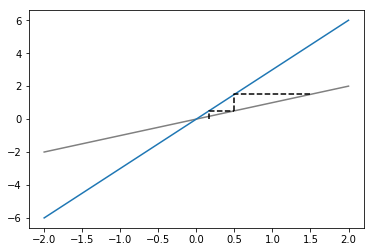

```python
# grows to infinity

xs = []
k = 5
x_range = (-2, 2 )

f = lambda x: 3 * x

x = 1 / 6
y = 0

xs = np.linspace( x_range[0], x_range[1] )

plt.plot( xs, xs, 'grey' )
plt.plot( xs, f(xs) )
for i in range( 2 ):
    y_next = f(x)
    x_next = y_next

    plt.plot( [x , x, x_next], [y, y_next, y_next], 'k--' )
    y = y_next
    x = x_next
plt.show()
```

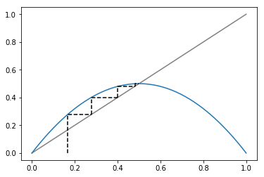

```python
# converges to a point

xs = []
k = 5
x_range = (0, 1 )

f = lambda x: 2 * x * ( 1 - x )

x = 1 / 6
y = 0

xs = np.linspace( x_range[0], x_range[1] )

plt.plot( xs, xs, 'grey' )
plt.plot( xs, f(xs) )
for i in range( 10 ):
    y_next = f(x)
    x_next = y_next

    plt.plot( [x , x, x_next], [y, y_next, y_next], 'k--' )
    y = y_next
    x = x_next
plt.show()
```

## 2019-01-17

A slope magnitude at a fixed point greater than one implies a source, less than one implies a sink.

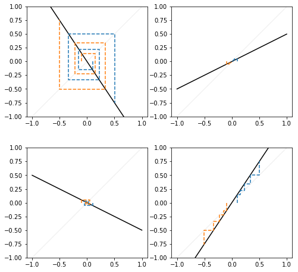

```python
x_range = np.linspace( -1.0, 1.0 )
fig, axs = plt.subplots( 2, 2, figsize = ( 8, 8 ) )
for i, m in enumerate( [-1.5, -0.5, 0.5, 1.5] ):
    ax = axs[i % 2][i // 2]
    f = lambda x: m * x
    ax.plot( x_range, x_range, c = 'grey', alpha = 0.1 )
    ax.plot( x_range, f(x_range), 'k' )

    ax.set_aspect( 'equal' )
    ax.set_ylim( [-1, 1] )
    plot_cobweb( ax, f, 0.1 )
    plot_cobweb( ax, f, -0.1 )

plt.show()
```

If $f(p) = p$ and $|f'(p)|< 1 \implies p$ is a sink or attracting fixed point.

If $\{p_1, p_2\}$ is a periodic 2 orbit and $|(f^2)'(p_1)|<1$, (i.e. $f(p_1) = p_2$ and $f(p_2) = p_1$), the period 2 orbit is a sink.

If $f(p) = p$ and $|f'(p)|> 1 \implies p$ is a source or repelling fixed point.

If $\{p_1, p_2\}$ is a periodic 2 orbit and $|(f^2)'(p_1)|>1$, the period 2 orbit is a source.

EX. $f(x) = 2x(1-x)$ and $f'(x) = 2 - 4x)$

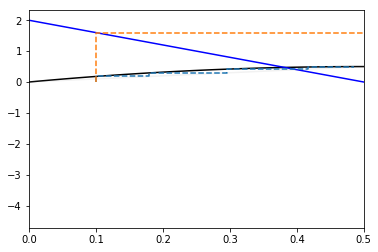

```python
f = lambda x: 2 * x * ( 1 - x )
f_prime = lambda x: 2 - 4 * x

x_range = np.linspace( 0, 0.5 )

fig, ax = plt.subplots()
ax.plot( x_range, f(x_range), 'k' )
ax.plot( x_range, f_prime(x_range), 'b' )

ax.plot( x_range, x_range, color='grey', alpha = 0.1 )
plot_cobweb( ax, f, x0 = 0.1 )
plot_cobweb( ax, f_prime, x0 = 0.1, iters = 2)
ax.set_xlim( [0, 0.5] )
plt.show()
```

## 2019-01-22

### Definition of a sink

The $\varepsilon$-neighborhood, $N_\varepsilon (p)$, of a point $p$ is the interval $\{x \in R : |x-p| < \varepsilon\}$. If $\exists \varepsilon > 0$ such that $\forall x \in N_\varepsilon(p), \lim_{k\to \infty} p^k (x) = p$ then we call $p$ a sink

### Definition of a source

If $\exists \varepsilon > 0$ such that all $x \in N_\varepsilon (p)$ except $p$ itself eventually go outside of $N_\varepsilon (p)$, then $p$ is a source.

### Orbits

Let $f$ be a map on the Reals. We call $p$ a periodic point of period $k$ if $f^k(p) = p$, and if $k$ is the smallest such positive integer. Let $f$ be a map and assume $p$ is a period $k$ point. The period $k$ orbit of $p$ is a periodic sink/source if $p$ is a sink/source for the map $f^k$.

$$( f \circ f )'(x) = f'( f(x))f'(x)$$ $$\{p_1, p_2\}: p_1 = f(p_2), p_2 = f(p_1)$$ $$(f^2)'(p_1) = f'(p_2)f'(p_1) = (f^2)'(p_2) = f'(p_1)f'(p_2)$$

The periodic orbit $\{p_1, p_2, \dots, p_k\}$ is a sink if $|f'(p_k)f'(p_{k-1})\cdots f'(p_1)| < 1 \quad \text{ source if } (>1)$

### Logistic curve family

$$g_a(x) = ax( 1 - x )$$

Supposed to be a simplistic model of population growth with a target steady population size. $a$ is the reproduction rate. Within $1 < a < 3$ there is a single fixed point. At 3 there is a bifurcation because the magnitude of the slope at the fixed point is $>1$. At various points between $3$ and $4$ there are more and more bifurcations. Known as a period doubling bifurcation.

This sequence of periodic sinks, one for each $n=1, 2, \dots, \infty$ of period $2^n$ is a period doubling cascade, a typical route to chaos in physical systems. If the $n^{\text{th}}$ period doubling occurs at $a = a_n$, then $\left\{\frac{a_2 - a_1}{a_3 - a_2}, \frac{a_3 - a_2}{a_4 - a_3} \right\}$, $\lim_{n\to\infty} \frac{a_{n+1} - a_n}{a_{n+2} - a_{n+1} } = 4.6692$ which is Feigehbaum's constant.

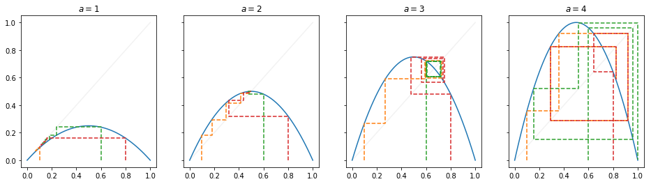

```python
# logistic = lambda a, x: a * x * ( 1 - x )

x_range = np.linspace( 0, 1, 100 )

fig, axs = plt.subplots( 1, 4, sharex = True, sharey = True, figsize = ( 16, 4 ) )
for i, ax in enumerate( axs ):
    ax.plot( x_range, x_range, color = 'grey', alpha = 0.1 )
    a = i + 1
    f = lambda x : a * x * ( 1 - x )
    ax.plot( x_range, f( x_range ) )
    ax.set_title( '$a = ' + str( a ) + '$' )
    plot_cobweb( ax, f, x0 = 0.1 )
    plot_cobweb( ax, f, x0 = 0.6 )
    plot_cobweb( ax, f, x0 = 0.8 )
```

#### Ex:

$$f(x) = 3.3x( 1 - x)$$ Has a periodic orbit of approximately $\{0.4794, 0.8236\}$. Want to check if its a source or a sink. $$(f^2)'( 0.4794 ) = f'( 0.4794 ) f'( 0.8236 ) = ( 3.3 - 6.6( 0.4794 ) )( 3.3 - 6.6 ( 0.8236 ) ) \approx -0.2904$$ So the period 2 orbit is a sink.

#### Ex:

$$f(x) = -x $$ Neutral fixed point at $0$. Every other point is part of a neutral period 2 orbit because $f^2(x) = x$ meaning every point is a fixed point for $f^2$.

## 2019 - 01 - 24

### Bifurcation Diagram

For the logistic map, perform iterations of the map for each value $a$. Throw away the beginning portion and plot the remaining.

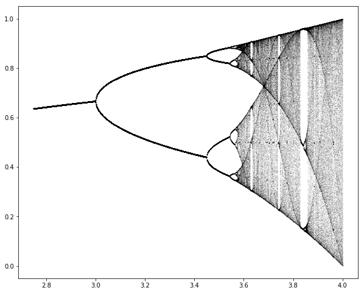

```python
n_a = 1000
n_pts = 5000
using = n_pts // 10
fig, ax = plt.subplots( figsize = ( 10, 10 ) )

for a in np.linspace( 2.75, 4, n_a ):
    g = lambda x : a * x * ( 1 - x )
    pts = [ np.random.random() ]
    for i in range( n_pts ):
        pts.append( g( pts[-1] ) )
    pts = pts[-using:]
    plt.scatter( [a] * len(pts), pts, c = 'k', s = 0.001 )
ax.set_aspect( 'equal' )
plt.show()
```

### Sensitivity

Let $f$ be a map on the reals. A point $x_0$ has *sensitive dependence on initial conditions (SDIC)* if $\exists \ d > 0$ such that any neighborhood of $x_0$ contains a point $x$ such that $|f^k(x) - f^k(x_0)| \geq d$ for some nonnegative integer $k$.

A point $x_0$ will be sensitive if it has heighbors as close as desired that eventually move away.

### Modular Maps

$$f(x) = 3x ( \text{ mod } 1 )$$ Two fixed points at $\{0, 0.5 \}$. Both are sources.

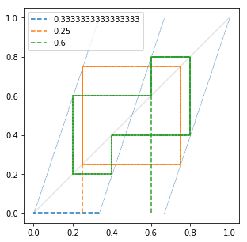

```python
xs = np.linspace( 0, 1, 1000 )
f = lambda x : ( 3 * x ) % 1

fig, ax = plt.subplots( figsize = ( 5, 5 ) )
plt.scatter( xs, f(xs), s = 0.01 )
plt.plot( xs, xs, color = 'grey', alpha = 0.2 )
plot_cobweb( ax, f, 1/3 )
plot_cobweb( ax, f, 1/4 )
plot_cobweb( ax, f, 6/10, 10)

plt.legend()
plt.gca().set_aspect( 'equal' )
plt.show()
```

### Eventually Periodic

We call a point *eventually periodic (EP)* with period $p$ for the map $F$ if for some positive integer $N$, $f^{n+p}(x) = f^n(x) \forall n \geq N,$ and if $p$ is the smallest such positive integer. In words this means the orbit of $x$ eventually maps onto a periodic orbit.

In our perivous example $\frac{1}{3^n}$ is eventually periodic with peroid 1 to 0. $\{\frac{1}{4}, \frac{3}{4}\}$ is periodic with period 2.

Any rational number between $(0, 1)$, it will be eventually periodic in this map with an orbit that is a source. Any irrational number is not eventually periodic.

### Itineraries

Splitting the function into bins along an axis, we can track a tracjectory through these bins. This is called an itinerary. If we call $x\leq1/2$ L, and $x> 1/2$ R, then For the map $G = 4x(1-x)$, each itinerary is unique. For $g = 2*x*(1-x)$, there are only two possible itineraries, $\overline{L}, R\overline{L}$.

```python
G = lambda x : 4 * x * ( 1 - x )

for i in range( 10 ):
    xs = [ np.random.random() ]

    for i in range( 50 ):
        xs.append( G( xs[-1] ) )

    itinerary = ''
    for x in xs:
        if x <= 0.5:
            itinerary += 'L'
        else:
            itinerary += 'R'
    print( str( xs[0] )[:10], itinerary )
```

```
0.21353283 LRRLRLLRLRRLRRLRRLRLLLRLRRLLLLRLRLLRLRLRLRRRLRRLRLL
0.55647420 RRLLRRLRRLRLLRLRRLRLLRRRLRRRLLRLLRLLLRRLRRLRLRLRRLR
0.94934220 RLRRLRRLRLLLLLLLLRLLLRLRRLLLRLLLRRRRLLRRLLLLLLRRLLR
0.90352454 RLRLRLRLRRLLLRLLRLLRLLLRLRRRRLLRLLLLLLLLLLLRRRLLLRL
0.16740304 LRRLLRRLRRRLRLRRRRLLLLRRRLLLLLRLLRLLLRRLRLRLRLLLRLR
0.34964867 LRLRLRLLRLLRLLRLRRLLLLRLRRLRLRLLRRRLRRLRRLLLLLLLRLR
0.72413492 RRRRLRRRLLLRLLLLRRRRRLLRRRRRRRLRRLLLLLLLLLRLRRRRRLL
0.90409603 RLRLRLRLRRRRRLLLLRLLRLRRRLRRRLRLLRLRLRLLRRLLRLLLLRL
0.04794153 LLRRLLRLLLLLLRLRLLRLLRRRRRRLRRLRLRLLRRLLRRLLRRRRRRR
0.07903367 LLRRRLLRLRLLRLLRRRLRRRLLLLRLLRRRRRRRLLRLRLRLLLLRRRR
```

```python
g = lambda x : 2 * x * ( 1 - x )

for i in range( 10 ):
    xs = [ np.random.random() ]

    for i in range( 50 ):
        xs.append( g( xs[-1] ) )

    itinerary = ''
    for x in xs:
        if x <= 0.5:
            itinerary += 'L'
        else:
            itinerary += 'R'
    print( str( xs[0] )[:10], itinerary )
```

```
0.50158397 RLLLLLLLLLLLLLLLLLLLLLLLLLLLLLLLLLLLLLLLLLLLLLLLLLL
0.99904106 RLLLLLLLLLLLLLLLLLLLLLLLLLLLLLLLLLLLLLLLLLLLLLLLLLL
0.60436208 RLLLLLLLLLLLLLLLLLLLLLLLLLLLLLLLLLLLLLLLLLLLLLLLLLL
0.34219958 LLLLLLLLLLLLLLLLLLLLLLLLLLLLLLLLLLLLLLLLLLLLLLLLLLL
0.33296618 LLLLLLLLLLLLLLLLLLLLLLLLLLLLLLLLLLLLLLLLLLLLLLLLLLL
0.28511749 LLLLLLLLLLLLLLLLLLLLLLLLLLLLLLLLLLLLLLLLLLLLLLLLLLL
0.54580677 RLLLLLLLLLLLLLLLLLLLLLLLLLLLLLLLLLLLLLLLLLLLLLLLLLL
0.54407332 RLLLLLLLLLLLLLLLLLLLLLLLLLLLLLLLLLLLLLLLLLLLLLLLLLL
0.45081291 LLLLLLLLLLLLLLLLLLLLLLLLLLLLLLLLLLLLLLLLLLLLLLLLLLL
0.64137125 RLLLLLLLLLLLLLLLLLLLLLLLLLLLLLLLLLLLLLLLLLLLLLLLLLL
```

## 2019-01-29

### Multi-dimensional maps

#### Hénon Maps

Hénon map is defined by $$f(x,y) = ( a-x^2 + by, x )$$ for some parameters $a,b$.

#### Pendulum

$$\ddot{\theta} = -c \dot{\theta} - \sin\theta + \rho \sin t$$

$c$ is friction, second term is gravity, $\rho$ is a force parameter.

[output not shown]

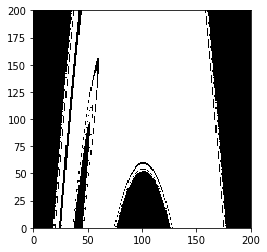

```python
a = 1.4
b = -0.3

H = lambda x, y: (a - x * x + b * y, x)

pts = []
N = 200
val_mat = np.zeros( (N, N, 2) )
last_pt = np.random.random( (N, N, 2) )
for i,x in enumerate( np.linspace(-2.5, 2.5, N ) ):
    for j,y in enumerate( np.linspace(-2.5, 2.5, N ) ):
        val_mat[i,j, :] = [x, y]

img_mat = np.zeros( (N, N) )

# pt = [-2.5, -2.5]
for g in range( 10 ): # iterations
    for i in range( N ):
        for j in range( N ):
            if img_mat[ i, j] == 0:
                pt = H( val_mat[i,j,0], val_mat[i,j,1] )

                if np.isclose(pt[0], last_pt[i,j,0]) and np.isclose(pt[1], last_pt[i,j,1]):
                    img_mat[i,j] = -1

                last_pt[i,j,:] = [val_mat[i,j,0], val_mat[i,j,1]]
                val_mat[i,j,:] = pt

            if abs(pt[0]) > 5.0 or abs(pt[1])>5.0:
                img_mat[i, j] = 1
    # print( g )
# print( img_mat )
# img_mat[img_mat == 0] = 1
# img_mat[img_mat < 0 ] = 0
plt.pcolormesh( img_mat.T, cmap = 'binary' )
plt.gca().set_aspect( 'equal' )
plt.show()
#     for pt in pts:
#         pt = H( pt[0], pt[1] )
```

## 2019 - 01 - 31

### Sinks, Sources, Saddles

The $\varepsilon$-neighborhood in two dimensions is a disk, $N$, aronud the fixed point. The eigenvalues of the Jacobian of $f$ on the fixed point determines the stability of the fixed point.

$$J = \begin{pmatrix} \frac{\partial f_1}{\partial x} & \frac{\partial f_1}{\partial y}\\ \frac{\partial f_2}{\partial x} & \frac{\partial f_2}{\partial y}\\ \end{pmatrix}$$

- All $|\lambda| <1 \implies \text{sink}$
- All $|\lambda| >1 \implies \text{source}$
- Any $|\lambda| > 1$ but not all $\implies \text{saddle}$

#### Hénon Map

The jacobian is $$J = \begin{pmatrix} -2x & 0.4\\ 1 & 0\\ \end{pmatrix}$$ $$J(0,0) = \begin{pmatrix} 0 & 0.4\\ 1 & 0\\ \end{pmatrix} $$

We can then find the eigenvalues about the origin $|J - \lambda I| = 0 \implies \lambda_1 = \sqrt{0.4}, \lambda_2 = -\sqrt{0.4}$, therfore the origin is a sink. The absolute value of the determinant of $J$ at the origin is $0.4$ implying the area of a circle after an iteration is 40% of the original circle.

$$J(-0.6, -0.6) = \begin{pmatrix} 1.2 & 0.4\\ 1 & 0\\ \end{pmatrix}$$ Finding the eigenvalues/eigenvectors gives us $\lambda_1 = 1.47, \lambda_2 = -0.27$ implying $(-0.6, -0.6)$ is a saddle.

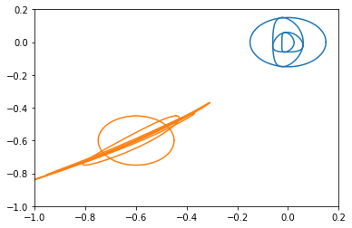

```python
a = 0
b = 0.4

H = lambda x, y: (a - x * x + b * y, x)

N = 100
# create circles
circle1 = np.zeros( ( N, 2 ) )
circle2 = np.zeros( ( N, 2 ) )

radius = 0.15
for i, theta in enumerate( np.linspace( 0, 2 * np.pi, N ) ):
    circle1[i,0] = np.cos( theta ) * radius
    circle1[i,1] = np.sin( theta ) * radius
    circle2[i,0] = -0.6 + np.cos( theta) * radius
    circle2[i,1] = -0.6 + np.sin( theta) * radius

n_iters = 3
plt.plot( circle1[:,0], circle1[:,1], 'C0' )
plt.plot( circle2[:,0], circle2[:,1], 'C1' )

# apply henon to circles
for j in range( n_iters ):
    for i in range( N ):
        circle1[i,:] = H( circle1[i,0], circle1[i,1] )
        circle2[i,:] = H( circle2[i,0], circle2[i,1] )

    plt.plot( circle1[:,0], circle1[:,1], 'C0' )
    plt.plot( circle2[:,0], circle2[:,1], 'C1' )

plt.ylim( [-1, 0.2 ] )
plt.xlim( [-1, 0.2 ] )
plt.show()
```

### Linear Maps

$$f(x,y) = A \begin{pmatrix} x \\ y \end{pmatrix} = \begin{pmatrix} a & b\\ c & d\\ \end{pmatrix} \begin{pmatrix} x\\ y\end{pmatrix} = ( ax + by, cx+ dy)$$

So the origin is a fixed point. Because the map is linear $J=A$, so we can directly take find the eigenvalues of $A$ to determine stablitiy.

#### Ex:

```
[2. 1.]
[2.5 2. ]
[3.5  3.25]
```

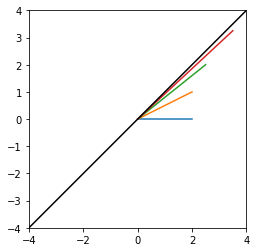

```python
A = np.array( [[ 1, 0.5 ],
               [ 0.5, 1 ] ] )

x = np.array( [ 2, 0 ] )
plt.plot( [0, x[0]], [0, x[1]] )
for i in range( 3 ):
    x = np.dot( A, x)
    plt.plot( [0, x[0]], [0, x[1]] )
    print( x )
plt.gca().set_aspect( 'equal' )
plt.plot( [-4, 4],[ -4, 4], 'k' )
plt.ylim( [-4, 4] )
plt.xlim( [-4, 4 ] )
plt.show()
```

## 2019 - 02 - 05

### Linear Maps

The points along the eigenvectors with eigenvalues of maginitude less than 1 form the stable manifold of the system. The points along the eigenvectors with eigenvalues of magnitude greater than 1 form the unstable manifold.

There can be :

### Non-Linear Maps and the Jacobian

#### Taylor Series:

In two dimensions $$\vec{f}(\vec{p}+\vec{h}) = \vec{f}(\vec{p}) + D\vec{f}(\vec{p}) \vec{h} + O( |\vec{h}|^2)$$ where $\vec{f}$ is a map, $\vec{p}$ is a point, $\vec{h}$ is a small perturbation, and $D$ is the Jacobian.

We want to know how $\vec{f}$ stretches and reshapes $\vec{h}$. If $\vec{p}$ is a fixed point, then the map $\vec{f}$ moves the point $\vec{p} + \vec{h}$ approximately $D\vec{f}(\vec{p})\vec{h}$ away from $\vec{p}$. For small $\vec{h}$, the action of the map $\vec{f}$ near $\vec{p}$ is essentially the same as the linear map that sends $\vec{h} \to D\vec{f}(\vec{p})\vec{h}$ which has a fixed point at $\vec{h} = 0$.

#### Theorem:

Let $\vec{f}$ be a map on $R^m$ with fixed point $\vec{f}(\vec{p}) = \vec{p}$.

1. If the magnitude of each eigenvalue of $D\vec{f}(\vec{p})$ is smaller than 1, $\vec{p}$ is a sink.
2. If the magnitude of each eigenvalue of $D\vec{f}(\vec{p})$ is greater than 1, $\vec{p}$ is a source.
3. Hyperbolic if none of the eigenvalues of $D\vec{f}(\vec{p})$ have magnitude 1. A hyperbolic $\vec{p}$ is a saddle if at least one eigenvalue has magnitude smaller than one and at least one eigenvalue has magnitude greater than one.

#### Ex:

$$a = 0.43, b = 0.4$$ $$f(x,y) = ( a - x^2 + by, x )$$ Period two sink $\{0.7, -0.1), (-0.1, 0.7)\}$ We can use the chain rule similar to the one-dimensional case. $$D\vec{f}^2(\vec{x}) = D\vec{f}(\vec{f}(\vec{x})) \times D\vec{f}(\vec{x})$$

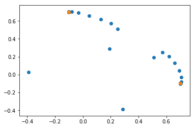

```
0.7 -0.0999999999999999
-0.0999999999999999 0.7
```

```python
a = 0.43
b = 0.4

f = lambda x, y: ( a - x * x + b * y, x )

x0 = np.random.random() - 0.5
y0 = np.random.random() - 0.5

xs = [x0]
ys = [y0]

for i in range( 100 ):
    x, y = f( xs[-1], ys[-1] )

    xs.append( x )
    ys.append( y )


plt.scatter( xs, ys )
plt.scatter( xs[-2:], ys[-2:] )
plt.show()
print( xs[-2], ys[-2] )
print( xs[-1], ys[-1] )
```

## 2019-02-07

### Stable and Unstable Manifolds

#### Definitions

If $\vec{p}$ is a fixed, saddle, or periodic point point:

- The *stable manifold* of $\vec{p}$, $S(\vec{p})$, is the set of points $\vec{v}$ such that $|\vec{f}^{\ n}(\vec{v})- \vec{f}^{\ n}(\vec{p})|\to 0$ as $n\to \infty$.
- The *unstable manifold* of $\vec{p}$, $U(\vec{p})$, is the set of $\vec{v}$ such that $|\vec{f}^{\ -n}(\vec{v}) - \vec{f}^{\ -n}(\vec{p})| \to 0$ as $n \to \infty$.

#### Finding Manifolds

For linear maps, $S$ and $U$ coincide with eigenvector direction. For nonlinear maps, $S$ is tangent to the eigenvector that corresponds to the shrinking direction at the saddle ( $|\lambda| < 1 $ ) and $U$ is tangent to the eigenvector that corresponds to the stretching direction at the saddle ( $|\lambda| > 1$ ).

#### Examples

Let $$f(x,y) = (2x, y/2)$$ This is a linear function so the Jacobian is just the function $$J = \begin{pmatrix}2 & 0 \\ 0 & 1/ 2\end{pmatrix}$$ Thus the eigenvalues are $\lambda = 2, 1/2$ becasue the matrix is diagonal, which implies the origin is a saddle point.

This corresponds with the eigenvectors $\vec{z}_1 = \begin{bmatrix} 1 \\ 0 \end{bmatrix}, \vec{z}_2 = \begin{bmatrix} 0 \\ 1 \end{bmatrix}$.

Let $$f(x,y) = \left( \frac{x}{2}, 2y - 7x^2 \right) $$ The origin is a saddle fixed point with $$J = \begin{pmatrix} 1/2 & 0 \\ -14x & 2 \end{pmatrix}$$ with $$\lambda_1 = 1/2, \vec{v}_1 = \begin{pmatrix} 1 \\ 0 \end{pmatrix}$$ $$\lambda_2 = 2, \vec{v}_2 = \begin{pmatrix} 0 \\ 1 \end{pmatrix}$$

$S$ is a quadratic tangential to $\vec{v}_1$ and $U$ is the $y$-axis. This divides the space

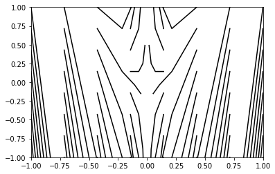

```python
f = lambda x, y: ( x / 2, 2 * y - 7 * x * x )
m = 8
for x in np.linspace( -1, 1, m ):
    for y in np.linspace( -1, 1, m ):
        # perform n iterates
        n = 3
        xs = [x]
        ys = [y]
        for i in range( n ):
            new_x, new_y = f( xs[-1], ys[-1] )
            xs.append( new_x )
            ys.append( new_y)
        plt.plot( xs, ys, 'k', alpha = 1.0 )
        # plt.scatter( xs, ys, color = 'k' )
plt.ylim( -1, 1 )
plt.xlim( -1, 1 )
plt.show()
```

Poincaré discovered that $S$ and $U$ can intersect at points distinct from saddle that defines them. Note: Neither $S$ nor $U$ cannot intersect itself. Assum $\vec{p}$ is a fixed ( or periodic) point and $\vec{h}_0\neq \vec{p}$ such that $\vec{h}_0 \in U, \vec{h}_0 \in S$, we call $\vec{h}_0$ a homoclinic point.

But $S$ and $U$ are invariant, so $\vec{f}(\vec{h}_0) = \vec{h}_1 \in S, \in U$ So all iterations of $\vec{h}_0$ are in both $S$ and $U$. Meaning there are infinitely many crossings.

If these $\vec{h}_0$ exist, then chaos is nearby because the map is highly sensitively dependent.

## 2019 - 02 - 12

### Matrix times Circle equals Ellipse

Let $N$ be the unit disc in $R^m$ and let $A$ be an $m\times m$ matrix. Let $s_1^2 \geq s_2^2 \geq \dots \geq 0$ and $\hat{u}_1, \hat{u}_2, \dots, \hat{u}_m$ be the eigenvalues and unit eigenvectors of the $m\times m$ matrix $AA^\intercal$

So for $R^2$, $$A\hat{v}_1 = s_1 \hat{u}_1, \quad A\hat{v}_2 = s_2 \hat{u}_2$$

meaning $s_1$ is the length of the major axis and $s_2$ is the length of the minor axis of the ellipse formed by $A$ on the unit disc. Note:

1. $\hat{u}_1, \hat{u}_2, \dots, \hat{u}_m$ are mutually orthogonal unit vectors
2. the axes of the ellipse $AN$ are $s_i\hat{u}_i$ for $1 \leq i \leq m$

#### Ex:

$$A = \begin{pmatrix} 1/2 & 1/2 \\ 0 & 2 \end{pmatrix}$$ Has eigenvalues $1/2, 2$ with eigenvectors $[1 \ 0]^\intercal$ and $[ 1 \ 3]^\intercal$. Because the fixed point is a saddle, these eigenvectors define the stable and unstable manifold respectively. To find the axes of the ellipse take $AA^\intercal$

$$\begin{align} AA^\intercal &= \begin{pmatrix} 1/2 & 1 \\ 1 & 4 \end{pmatrix} \end{align}$$ This has eigenvalues $s_1^2 = 4.3, s_2^2 = 0.23$ and eigenvectors $\hat{u}_1 = \begin{bmatrix} 0.26 \\ 0.97 \end{bmatrix}, \hat{u}_2 = \begin{bmatrix} -0.97 \\ 0.26 \end{bmatrix} $ And $s_1 \approx 2.07$, $s_2 \approx 0.48$.

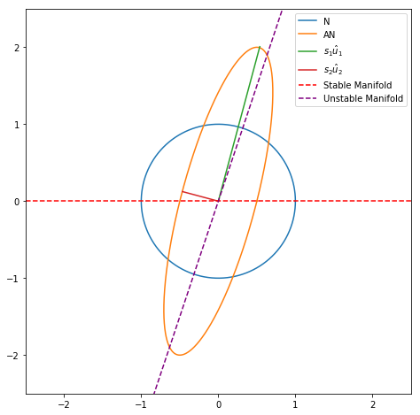

```python
A = np.array( [ [ 0.5, 0.5 ], [ 0, 2 ] ] )


npoints = 1000
circle = np.zeros( (npoints, 2 ) )
ellipse = np.zeros( ( npoints, 2 ) )
for i in range( npoints ):
    x = np.cos( 2 * np.pi * i / ( npoints - 1 ) )
    y = np.sin( 2 * np.pi * i / ( npoints - 1 ) )

    in_vec = np.array( [x, y] )
    out_vec = np.dot( A, in_vec )

    circle[i, :] = in_vec
    ellipse[i, :] = out_vec

plt.figure(figsize=(8, 8))

plt.ylim( [-2.5, 2.5] )
plt.xlim( [-2.5, 2.5] )
plt.gca().set_aspect( 'equal' )
plt.plot( circle[:,0], circle[:,1], label = 'N')
plt.plot( ellipse[:,0], ellipse[:,1], label = 'AN' )

lam1 = [1, 0]
lam2 = [1, 3]

s1 = 2.07
s2 = 0.48
u1 = [0.26, 0.97]
u2 = [-0.97, 0.26]

plt.plot( [0, s1 * u1[0] ], [0, s1 * u1[1] ], label = '$s_1 \hat{u}_1$' )
plt.plot( [0, s2 * u2[0] ], [0, s2 * u2[1] ], label = '$s_2 \hat{u}_2$' )

plt.plot( [-2.5 * lam1[0], 2.5 * lam1[0]], [ -2.5 * lam1[1], 2.5 * lam1[1] ], 'r--', label = 'Stable Manifold' )
plt.plot( [-2.5 * lam2[0], 2.5 * lam2[0]], [ -2.5 * lam2[1], 2.5 * lam2[1] ], '--', color='purple', label = 'Unstable Manifold' )
plt.legend()
plt.show()
```

## 2019 - 02 - 14

### Seen Behaviors:

- Fixed points
  - sources
  - sinks
  - saddles
- Periodic points
  - sources
  - sinks
  - saddles
- Unbounded

Most of the unstbale behavior we've seen has been transient and ultimately gives way to stable behavior, but initial conditions do not need to be attracted to $\infty$ or to a periodic orbit.

### Lyapunov Exponents

Let $f$ be a continuous map on $R$. The *Lyapunov number* $L(x_1)$ of the orbit $\{x_1, x_2, \dots \}$ $$L(x_1) = \lim_{n\to\infty} \left( |f'(x_1)||f'(x_2)|\dots|f'(x_n)|\right)^{1/n}$$ If this limit exists, then the Lypapunov exponent is $$h(x_1) = \ln( L(x_1) )$$ $$h(x_1) = \lim_{n\to\infty} \frac{1}{n} \left( \ln|f'(x_1)| +\ln |f'(x_2)| + \dots + \ln |f'(x_n)|\right)$$ An $h>0$ will imply stretching and $h<0$ implies shrinking.

#### Ex:

If $x_1$ is a sink fixed point with $f'(x_1) = 1/2$ then $$L(x_1) = (1/2)^{n/n} = 1/2$$ and $$h(x_1) = \ln( 1/2 ) = - \ln 2$$ Further, everything in the basin of the sink will have the same $L$ number.

If there is a fixed point source $x_0$ then $h(x_0) > 0, L(x_0) > 0$ and if it is a sink $h(x_0) < 0, L(x_0) < 1$.

### Asymptotically Periodic

Let $f$ be a smooth map on $R$ an orbit give by $\{x_1, x_2, \dots, x_n \}$ is called asymptotically periodic if it converges to a periodic orbit as $n\to\infty$. That is, there exists a periodic orbit $\{y_1, y_2,\dots, y_k\}$ such that $$\lim_{n\to\infty} |x_n - y_n| = 0$$ Differs from eventually periodic in that the orbit simply needs to approach a periodic orbit instead of eventually taking the exact value of the orbit.

### Chaotic Orbits

Lef $f$ be a smooth map on $R$ and let $\{x_1, x_2, \dots \}$ be an orbit of $f$. The orbit is chatic if

1. The orbit is bounded
2. The orbit is not asymptotically periodic
3. The Lyapunov exponenent, $h > 0$

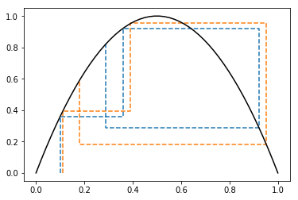

```python
# spreading of the logistic map when a = 4
G = lambda x : 4 * x * ( 1 - x )

xs = np.linspace( 0, 1 )
fig, ax = plt.subplots()

x1 = 0.1
x2 = 0.11

plot_cobweb( ax, f = G, x0 = x1, iters = 4 )
plot_cobweb( ax, f = G, x0 = x2, iters = 4 )
ax.plot( xs, G( xs ), 'k' )
plt.show()
```

### Ex

$$f(x) = 2x \mod 1$$ Every point has a slope of 2. There is a fixed point source at $x = 0$. There is a periodic orbit at $\{1/3, 2/3\}$. All the irrational numbers lead to chaotic orbits.

## 2019 - 02 - 19

Continuing with examples of chaotic orbits

#### Ex

A bounded orbit that is not asymptotically periodic and deos not exhibit sensitivity dependence on initial conditions is quasi-periodic.

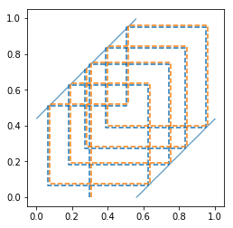

```python
q = ( np.pi - 3 ) + 0.3 # using pi to generate a irrational

f = lambda x : ( x + q ) % 1

xs = np.linspace( 0, 1, 1000 )

plt.scatter( xs, f(xs), s = 0.01 )

plot_cobweb( ax = plt.gca(), f = f, x0 = 0.3, iters = 10 )
plot_cobweb( ax = plt.gca(), f = f, x0 = 0.31, iters = 10 )
plt.gca().set_aspect( 'equal' )
plt.show()
```

#### Ex

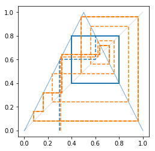

```
LRRLRLRLRLRLRLRLRLRL
LRRLRLLLRRRRLLRLLLRR
```

```python
def f_single(x):
    if x >= 0 and x <= 1/2:
        return 2 * x
    else:
        return 2 * ( 1 - x )

f = np.vectorize( f_single )

xs = np.linspace( 0, 1, 1000 )

plt.scatter( xs, f(xs), s = 0.01 )
plt.plot( xs, xs, color = 'k', alpha = 0.1 )
xs1 = plot_cobweb( ax = plt.gca(), f = f, x0 = 0.3, iters = 20 )
xs2 = plot_cobweb( ax = plt.gca(), f = f, x0 = 0.31, iters = 20 )

plt.gca().set_aspect( 'equal' )
plt.show()


# print itineraries
for xs in [xs1, xs2]:
    itinerary = ''
    for x in xs:
        if x <= 0.5:
            itinerary += 'L'
        else:
            itinerary += 'R'
    print( itinerary )
```

##### Theorem: The Tent map has infinitely many chaotic orbits.

The tent map has $h(x) = \ln 2 > 0, \forall x $ except $x$ where the orbit lands on $1/2$ where the slope is not continuous. Everything between $0$ and $1$ is bounded. There are no sinks, so the only asymptotically periodic orbits are the eventually periodic orbits e.g. $3/10$ or any other rational number. Any irrational initial condition will have a chaotic orbit.

### Conjugacy and the Logistic Map

We want to show that $G$ has chaotic orbits, we'll do it by comparing with the Tent Map $T$.

For each point, $x$, in the Tent Map domain, there is a companion point $C(x)$ in the domanin of $G$ that imitates its dynamics exactly. We say $f$ and $g$ are *conjugate* if they are related by a continuous, one-to-one, change of coordinates, i.e. $C(f(x)) = g(C(x))$.

For the tent map to be conjugate with the tent map $$C(x) = \frac{ 1 - \cos(\pi x)}{2}$$ Which means $C(T(x)) = G(C(x)), \ \forall x \in [0,1]$

For $0 \leq x \leq 1/2$

\begin{align} G(C(x)) &= 4\frac{1 - \cos{\pi x}}{2} \left( 1 - \frac{1 - \cos{\pi x}}{2}\right)\\ &= 1 - \cos^2{\pi x}\\ &= \sin^2{\pi x}\\ \end{align} and \begin{align} C(T(x)) &= \frac{1 - \cos{\pi T(x)}}{2}\\ &= \frac{1 - \cos{2 \pi x}}{2}\\ &= \sin^2{\pi x} \end{align}

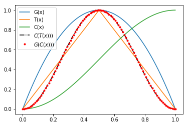

```python
def tent ( x ):
    if x >= 0 and x <= 1/2:
        return 2 * x
    else:
        return 2 * ( 1 - x )
T = np.vectorize( tent )
G = lambda x: 4 * x * ( 1 - x )
C = lambda x: ( 1 - np.cos( np.pi * x ) ) / 2.0

xs = np.linspace( 0, 1, 100 )

plt.plot( xs, G(xs), label = 'G(x)' )
plt.plot( xs, T(xs), label = 'T(x)' )
plt.plot( xs, C(xs), label = 'C(x)' )
plt.plot( xs, C(T(xs)), 'k-.', label = '$C(T(x)))$' )
plt.plot( xs, G(C(xs)), 'r.', label = '$G(C(x)))$' )
plt.legend()
plt.show()
```

#### Idea:

There are two ways to get from domain of $G$ to range of $G$ after $n$ iterates.

1. Evaluate $G^{n}(x)$ which may be expensive
2. Evaluate $C \circ T^{n} \circ C^{-1}(x) = G^{n}(x)$ which may be cheaper

## 2019 - 02 - 21

### Transition Graphs

##### Brower's Fixed Point Theorem:

Let $f$ be a continuous map on $R$ and let $I = [a,b]$ be an interval such that $I \subseteq f(I)$. Then $f$ has a fixed point in $I$.

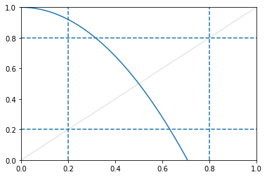

```python
a = 0.2
b = 0.8
f = lambda x: 1 - 2 * x*x

xs = np.linspace( 0, 1 )
plt.plot( xs, f(xs) )
plt.plot( xs, xs, 'k', alpha = 0.1 )
plt.axvline( a, ls = '--' )
plt.axvline( b, ls = '--' )
plt.axhline( a, ls = '--' )
plt.axhline( b, ls = '--' )

plt.ylim( [0, 1] )
plt.xlim( [0, 1] )
plt.show()
```

A partition of the interval $I$ is a collection of subintervals which are pairwise disjoint (except for the endpoints) whose union is $I$. for example $\{L, R\}$ we've seen previously in itineraries.

To make a transition graph describing the dynamics on partitions, we'll draw an arrowfrom $A$ to $B$ if and only if $f(A) \supseteq B$, that is $f(A)$ covers $B$.

Transition graph for the tent map and $G$ logistic map.

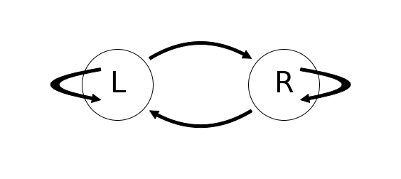

```python
L = (0,0)
R = (1,0)

plt.figure()
plt.axis('off')
plt.scatter( [L[0], R[0]], [L[1], R[1]], s = 10000, edgecolors = 'k', facecolors = 'w' )
plt.annotate('', xy=L, xytext=R,
             arrowprops=dict(facecolor='black',
                             connectionstyle = 'arc3,rad=-0.5',
                             shrink=0.25),
            )
plt.annotate('', xy=R, xytext=L,
             arrowprops=dict(facecolor='black',
                             connectionstyle = 'arc3,rad=-0.5',
                             shrink=0.25),
            )
plt.annotate('', xy=(L[0] - 0.1, L[1]-0.05),
             xytext=(L[0] - 0.1, L[1]+0.05),
             arrowprops=dict(facecolor='black',
                             connectionstyle = 'arc3,rad=+3',
                             ),
            )
plt.annotate('', xy=(R[0] + 0.1, R[1]-0.05),
             xytext=(R[0] + 0.1, R[1]+0.05),
             arrowprops=dict(facecolor='black',
                             connectionstyle = 'arc3,rad=-3',
                             ),
            )

plt.text( L[0], L[1], 'L', fontsize = 40,
          horizontalalignment='center',
          verticalalignment='center'
        )
plt.text( R[0], R[1], 'R', fontsize = 40,
          horizontalalignment='center',
          verticalalignment='center'
        )
plt.show()
```

Continuous functions preserve continuity under composition. $$A\subseteq B \implies f(A) \subseteq f(B)$$ so if $A\to B \to C$ is an allowable path in a transition graph, then $f(A)\supseteq B$ and $f(B) \supseteq C$ and $f^2(A) \supseteq f(B) \implies f^2(A) \supseteq C$.

If the sequence $s_1s_2\dots s_{k+1}$ is an allowable path, for example $LRRR\cdots LRL$ then $f^k(s_1) \supseteq s_{k+1}$

If we assume that $s_1s_2\dots s_k s_1$ is an allowable path, then $f^k(s_1) \supseteq s_1$ which implies $f^k$ must have a fixed point in the subinterval $s_1,s_2,\dots,s_k$.

#### EX:

For the tent map, $T$, the itinerary $LRRRL$ means the sub interval $LRRR$ has in it a fixed point of $T^4$. The points of the period four orbit are $\{ \overline{LRRR}, \overline{RRRL}, \overline{RRLR}, \overline{RLRR} \}$

```python
#           ___
#         |    |
#   I --> J <--
#  ||     |
#   K <---
```

Allowable itineraries under the $I$, $J$, $K$ transition graph.

- $\overline{J}$
- $\overline{IK}$
- $\overline{KI}$
- $J\overline{IK}$
- $J\overline{KI}$

## 2019 - 02 - 26

### Basin of Attraction

Let $\vec{f}$ be a map on $R^n$ and let $\vec{p}$ be an attracting fixed point (sink) or periodic point for $\vec{f}$, the *basin of attraction* of $\vec{p}$ is the set of points $\vec{x}$ such that the $\lim_{k\to\infty} \left|\vec{f^{k}}(\vec{x}) - \vec{f^{k}} (\vec{p}) \right| = 0$

#### Ex

$$f(r, \theta ) = ( r^2, \theta - sin\theta )$$ Fixed points:

- $(0, 0)$ - sink
- $(1, \pi)$ - source
- $(1, 0)$ - saddle

The stable manifold of the point $(1,0)$ is $U \setminus \{(1, \pi)\}$ where $U$ is the unit circle. The basin of attraction for the origin is the interior of the unit circle.

### Schwartzian:

Let $f$ be a smooth map on $R$. The Schwartzian derivative of $f$ is defined by $$S(f(x)) = \frac{f'''(x)}{f(x)} - \frac{3}{2}\left( \frac{f''(x)}{f'(x)}\right )^2$$

We say that a function $f$ has a negative Schwartzian if $S(f(x))$ is negative whenever $f'(x)\neq 0$.

#### Ex

The Schwartzian of $g_a(x) = ax( 1 - x )$ is always negative.

##### Theorem:

If the map $f$ on $R$ has a negative Schwartzian, and if $p$ is a fixed or periodic point of $f$, then either:

1. The basin of attraction of $p$ contains an interval of infinite length
2. There is a critical point $c$ such that $f'(c) = 0$ in the basin of $p$.
3. $p$ is a source

##### Proof:

Assume $p$ is neither a source nor a sink with an infinite basin. We show that $f'(c) = 0$ for some $c$ in the basin of $p$. Consider first the case where $p$ is a fixed point and $f'(p) \geq 0$. This argument will generalize to $f'(p) < 0$ and higher periods. If $f'(p) = 0$ then the fixed point attracts itself and we are done. We know $f(p) = p$ and $0< f'(p) < 1$. Note that $f'(x)$ cannot be constant in the neighborhood of $p$ since that would imply $f'' = f''' = 0$ and $S(f) = 0$. Also, since $p$ doesn't have an infinite basin, $f$ cannot simply monotonically increase or decrease within the lines $y=x$ and $y = -x + 2p$. Either $f$ has a critical point within the basin of $p$ or there exists an interval $(a,b)$ in the basin of $p$ with $p\in(a,b)$ such that $f'(a) \geq 1$ and $f'(b)\geq 1$. Since $f'(p) < 1$ and $(a,b)$ exists there is a local maximum $m$ for $f'$ in the basin of $p$. i.e. an inflection point of $f$ and a place where $f''(m) = 0, f'''(m) >0$due to concatvity switch of $f$ from down to up. Therefore $S(f(m)) = \frac{f'''(m)}{f'(m)}$. Since $S(f(m))$ is assumed to be negative and $f'''(m) \geq 0$ then we must have $f'(m)<0$.

## 2019 - 03 - 19

### Fractals

The mathematics of roughness You may be a fractal if you have:

- Complicated structure at many length/time scales
- self-similarity
- non-integer or fractal dimension

#### Cantor Set

Start with an interval $$k_0 = [0, 1]$$ Now take the middle third of the set with each successive iteration \begin{align*} k_1 &= [0, 1/3] \cup [2/3, 1]\\ k_2 &= [0, 1/9] \cup [2/9, 1/3] \cup [2/3, 7/9] \cup [8/9, 1] \end{align*}

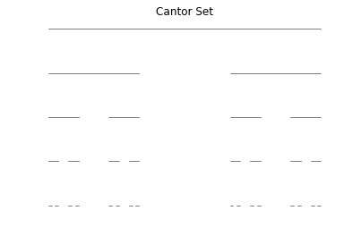

```python
def remove_middle_third( interval ):
    left = interval[0]
    right = interval[1]
    size = right - left

    return [ ( left, left + size / 3 ),
             ( right - size / 3, right ) ]

def get_bounds( n, interval = ( 0, 1 ) ):

    if n == 0:
        return [ interval ]
    else:
        left_interval, right_interval = remove_middle_third( interval )
        left_bound = get_bounds( n - 1, left_interval )
        right_bound = get_bounds( n - 1, right_interval )
        output = []
        for l in left_bound:
            output.append( l )
        for r in right_bound:
            output.append( r )
        return output

for i in range( 5 ):
    intervals = get_bounds( i )

    for interval in intervals:
        plt.plot( interval, [-i, -i], 'k', lw = 0.5 )
plt.axis( 'off' )
plt.title( 'Cantor Set' )
plt.show()
```

Questions to ask:

1. What is the length of $k_\infty$
2. Does $k_\infty$ contain any intervals?
3. Is $k_\infty$ simply the endpoints of the intervals we remove at each stage?

We can answer the first question by takeing the limit of the length. $k_n$ is a set of $2^n$ intervals, each of length $3^{-n}$. So $k_n$ is $\frac{2^n}{3^n}$ in length. If we take the limit we see $$k_\infty \text{ length } : \lim_{n\to\infty} \left(\frac{2}{3}\right)^n = 0$$

We see that this inherently means $k_\infty$ does not contain any intervals, because if it did, they would have length.

Finally, the answer to the third question is no.

### Countability

A set is countable if it can be put into a 1-1 correspondence with the natural numbers.

A set is uncountable if it is not countable